# DSO 522: In-Class Workbook 7

Matteo Sesia

October 1, 2024

# Instructions

Your task is to edit this R Markdown notebook to include your solutions, ensuring that it is well-organized and professional in appearance. Answers must be clear and concise. Start by downloading the Rmd file.

**Collaboration Policy.** You are allowed to discuss this workbook with your classmates and work in groups. Despite group discussions, each student must write and submit their own solutions.

**Assistance Policy.** You may ask for clarifications from the instructor and teaching assistant in class. Do not seek help on these workbooks outside of class, as they are intended to be completed during class time.

**Submission Requirements.** Solutions must be submitted on Brightspace as a PDF writeup. Use the ‘Knit to PDF’ feature in RStudio to prepare your PDF document. Ensure that your PDF document looks like the provided PDF version of the workbook, including all code used to obtain the results in proper code blocks. Make sure your PDF writeup includes *your name* in the title (replace my name with yours).

**Grading Criteria.** This workbook is worth 10 points. To achieve a grade of 10, your writeup must correctly answer all questions, be easy to understand, and be formatted correctly.

**Work Timeline.** You are expected to work on this assignment in class, but you may complete it at home within 24 hours. It is due on October 9, 2024, at 9:30 pm. Late submissions will incur a 50% deduction for any initial delay below 24 hours, and an additional 10% deduction for each additional day.

Remember, you will need to use the `fpp3` package to complete this assignment, as shown in the lecture.

```r
suppressMessages(library(fpp3))
```

**NOTE:** only Problem 1 needs to be completed in order to receive full credit for this assignment. Problems 2 and 3 are optional.

# Problem 1

Data set `global_economy` contains the annual Exports from many countries. We will analyze data from Argentina.

1. Plot the Exports series and discuss the main features of the data.
2. Use an ETS(A,N,N) model to forecast the series, and plot the forecasts.
3. Compute the RMSE values for the training data.
4. Compare the results to those from an ETS(A,A,N) model. (Remember that the trended model is using one more parameter than the simpler model.) Discuss the merits of the two forecasting methods for this data set.
5. Compare the forecasts from both methods. Which do you think is best?
6. Calculate a 95% prediction interval for the first forecast for each series.

# Problem 1 Solutions

> 1. Plot the Exports series and discuss the main features of the data.

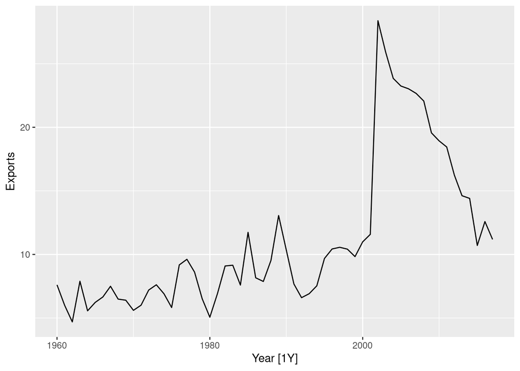

```r
global_economy |>
  filter(Country == "Argentina") |>
  autoplot(Exports)
```

There is a huge jump in Exports in 2002, due to the deregulation of the Argentinian peso. Since then, Exports (as a percentage of GDP) has gradually returned to 1990 levels.

> 2. Use an ETS(A,N,N) model to forecast the series, and plot the forecasts.

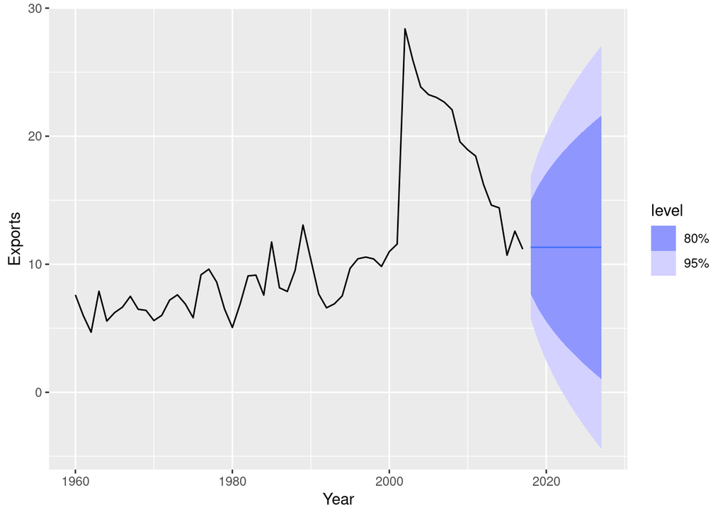

```r
etsANN <- global_economy |>
  filter(Country == "Argentina") |>
  model(ETS(Exports ~ error("A") + trend("N") + season("N")))
etsANN |>
  forecast(h = 10) |>
  autoplot(global_economy)
```

> 3. Compute the RMSE values for the training data.

```r
accuracy(etsANN) |> select(RMSE)
```

| RMSE |
| --- |
| 2.776087 |

> 4. Compare the results to those from an ETS(A,A,N) model. (Remember that the trended model is using one more parameter than the simpler model.) Discuss the merits of the two forecasting methods for this data set.

```r
fit <- global_economy |>
  filter(Country == "Argentina") |>
  model(
    ses = ETS(Exports ~ error("A") + trend("N") + season("N")),
    holt = ETS(Exports ~ error("A") + trend("A") + season("N"))
  )
glance(fit)
```

| Country | .model | sigma2 | log_lik | AIC | AICc | BIC | MSE | AMSE | MAE |
| --- | --- | --- | --- | --- | --- | --- | --- | --- | --- |
| Argentina | ses | 7.981898 | -176.9733 | 359.9466 | 360.3911 | 366.1279 | 7.706660 | 13.81169 | 1.619605 |
| Argentina | holt | 8.279549 | -176.9804 | 363.9608 | 365.1147 | 374.2630 | 7.708546 | 13.72724 | 1.638405 |

There is very little difference in training RMSE between these models. So the extra parameter is not doing much.

> 5. Compare the forecasts from both methods. Which do you think is best?

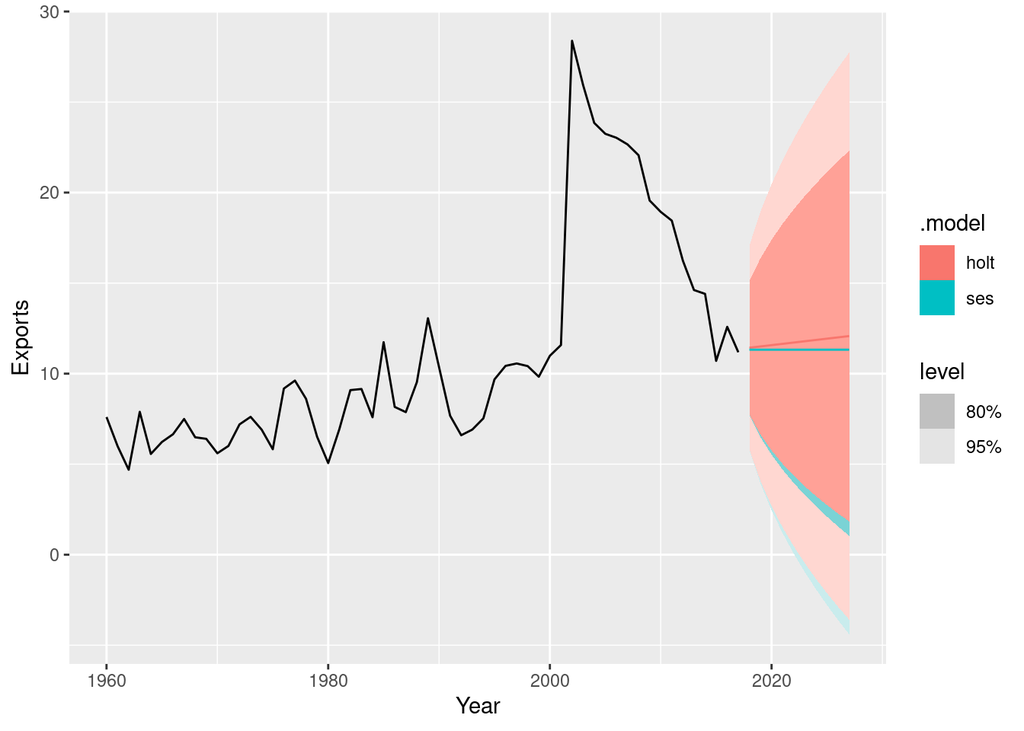

```r
fit |>
  forecast(h = 10) |>
  autoplot(global_economy)
```

- The forecasts are similar. In this case, the *simpler* model may be preferred. However, it may also be reasonable to expect an upward trend in these data.
> 6. Calculate a 95% prediction interval for the first forecast for each series.

```r
fit |>
  forecast(h = 1) |>
  mutate(PI = hilo(Exports, level = 95))
```

| Country | .model | Year | Exports | .mean | PI |
| --- | --- | --- | --- | --- | --- |
| Argentina | ses | 2018 |  | 11.32310 |  |
| Argentina | holt | 2018 |  | 11.43121 |  |

# Problem 2

Find an ETS model for the Gas data from `aus_production` and forecast the next 5 years. Why is multiplicative seasonality necessary here? Experiment with making the trend damped. Does it improve the forecasts?

# Problem 2 Solutions

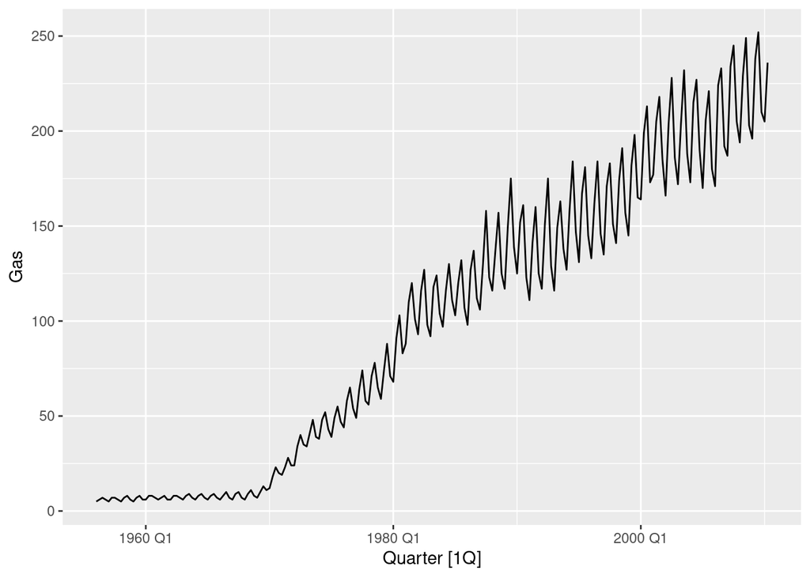

```r
aus_production |> autoplot(Gas)
```

- There is a huge increase in variance as the series increases in level. => That makes it necessary to use multiplicative seasonality.

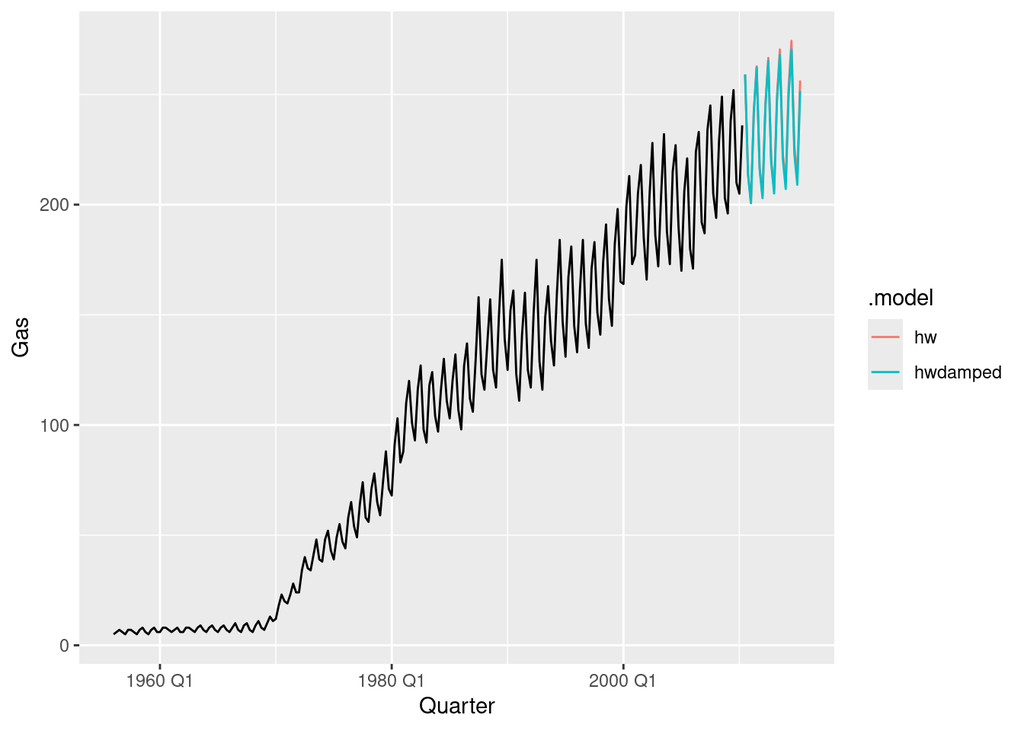

```r
fit <- aus_production |>
  model(
    hw = ETS(Gas ~ error("M") + trend("A") + season("M")),
    hwdamped = ETS(Gas ~ error("M") + trend("Ad") + season("M")),
  )

fit |>
  forecast(h = "5 years") |>
  autoplot(aus_production, level=NULL)
```

```r
fit |> glance()
```

| .model | sigma2 | log_lik | AIC | AICc | BIC | MSE | AMSE | MAE |
| --- | --- | --- | --- | --- | --- | --- | --- | --- |
| hw | 0.003244894 | -831.4643 | 1680.929 | 1681.794 | 1711.389 | 21.11507 | 32.16296 | 0.04134491 |
| hwdamped | 0.003285280 | -832.0139 | 1684.028 | 1685.091 | 1717.873 | 21.08500 | 32.04319 | 0.04165944 |

- The non-damped model seems to be doing slightly better here, probably because the trend is very strong over most of the historical data.

Let’s look at the fitted model (without damping).

```r
fit |> tidy()
```

| .model | term | estimate |
| --- | --- | --- |
| hw | alpha | 0.65285449 |
| hw | beta | 0.14416745 |
| hw | gamma | 0.09784922 |
| hw | l[0] | 5.94559214 |
| hw | b[0] | 0.07062881 |
| hw | s[0] | 0.93092356 |
| hw | s[-1] | 1.17788274 |
| hw | s[-2] | 1.07485100 |
| hw | s[-3] | 0.81634270 |
| hwdamped | alpha | 0.64890445 |

[output cut: 9 more lines]

```r
fit |>
  augment() |>
  filter(.model == "hw") |>
  features(.innov, ljung_box, lag = 24)
```

| .model | lb_stat | lb_pvalue |
| --- | --- | --- |
| hw | 57.1136 | 0.0001613395 |

Let’s look at the residuals.

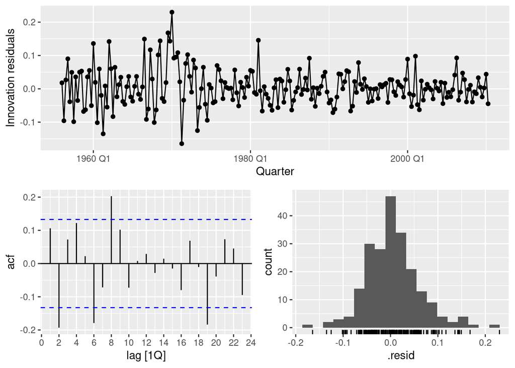

```r
fit |>
  select(hw) |>
  gg_tsresiduals()
```

- There is still some small *correlations* left in the residuals, showing the model has not fully captured the available information.
- There also appears to be some *heteroskedasticity* in the residuals with larger variance in the first half the series.

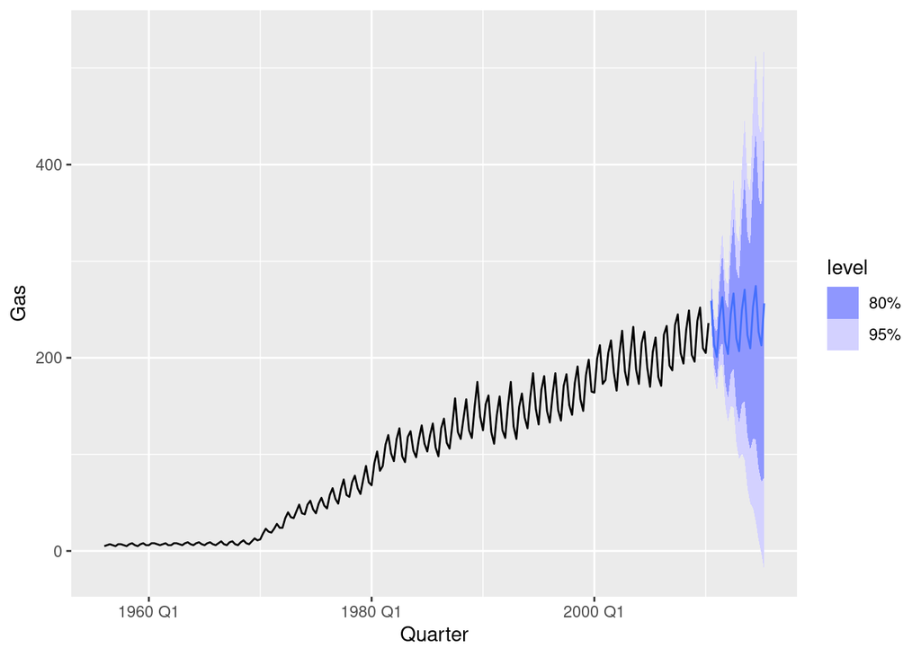

```r
fit |>
  forecast(h = "5 years") |>
  filter(.model == "hw") |>
  autoplot(aus_production)
```

While the point forecasts look ok, the intervals are excessively wide.

Alternatively, we can try using an ETS(A,A,A) model after a box-cox transformation.

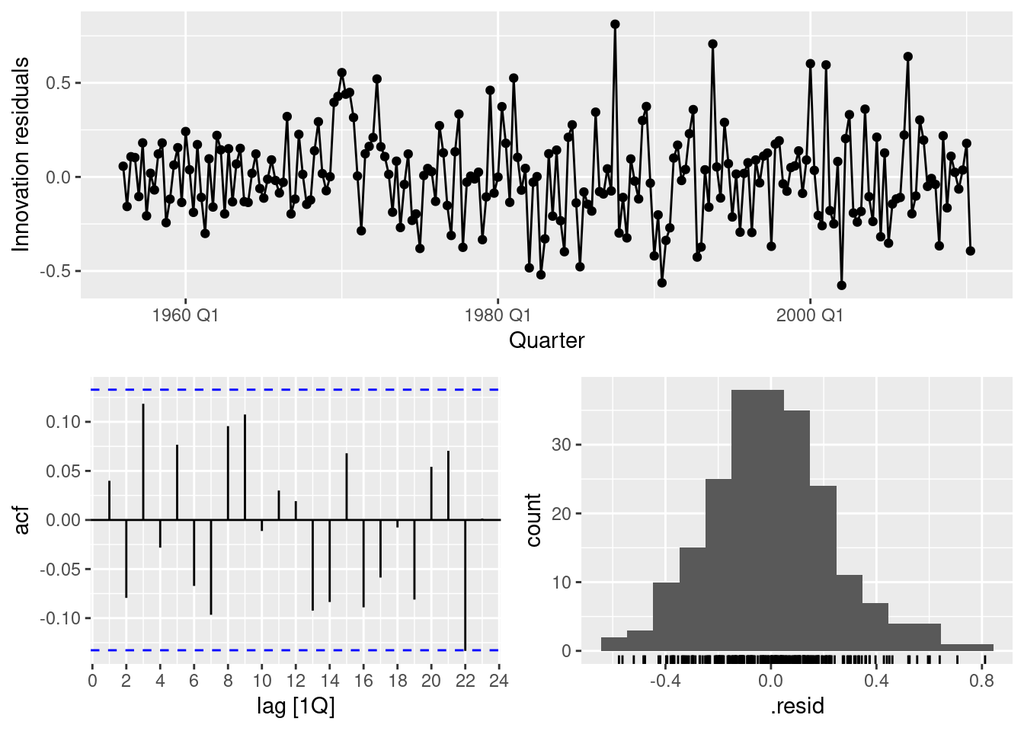

```r
fit <- aus_production |>
  model(
    hw = ETS(Gas ~ error("M") + trend("A") + season("M")),
    hw.box.cox = ETS(box_cox(Gas,0.4) ~ error("A") + trend("A") + season("A")),
  )

fit |>
  select(hw.box.cox) |>
  gg_tsresiduals()
```

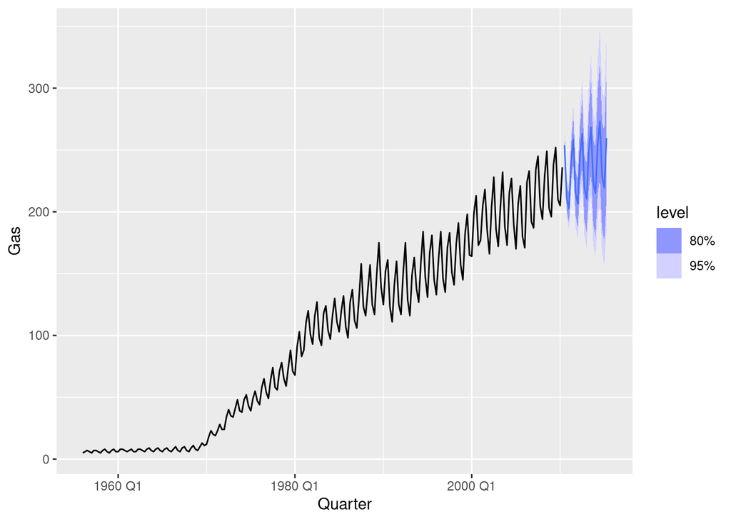

```r
fit |>
  forecast(h = "5 years") |>
  filter(.model == "hw.box.cox") |>
  autoplot(aus_production)
```

# Problem 3

1. Apply cross-validation techniques to produce 1 year ahead ETS and seasonal naive forecasts for Portland cement production (from `aus_production`). Use a stretching data window with initial size of 5 years, and increment the window by one year at a time.
2. Compute the RMSE of the resulting $4$-step-ahead errors. Comment on which forecasts are more accurate. Is this what you expected?

# Problem 3 Solutions

> 1. Apply cross-validation techniques to produce 1 year ahead ETS and seasonal naive forecasts for Portland cement production (from `aus_production`). Use a stretching data window with initial size of 5 years, and increment the window by one year at a time.

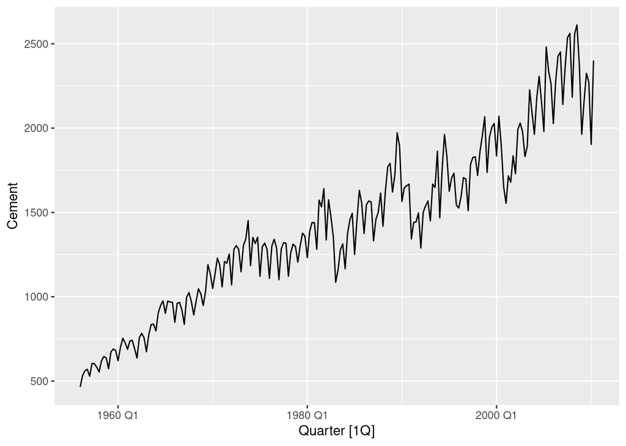

```r
aus_production |> autoplot(Cement)
```

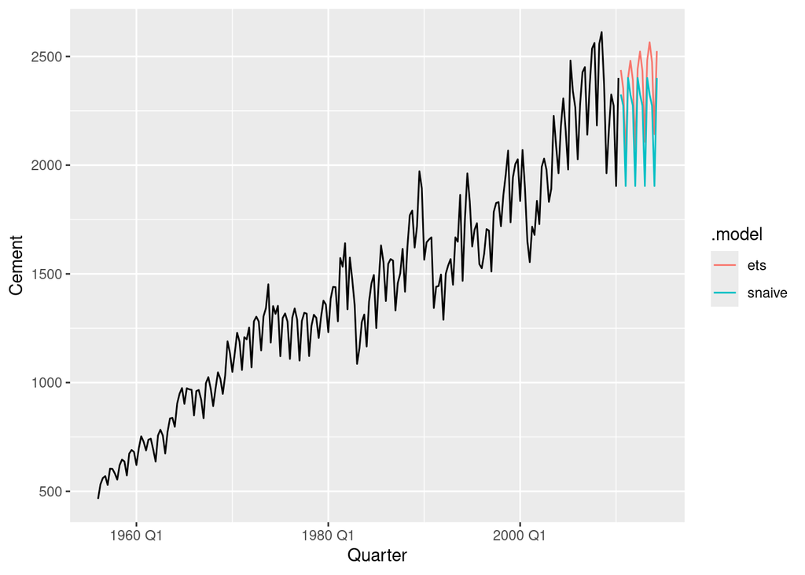

```r
fc <- aus_production |>
  model(ets = ETS(Cement ~ error("M") + trend("A") + season("M")),
        snaive = SNAIVE(Cement)) |>
  forecast(h = "4 years")
fc |>
  autoplot(aus_production, level=NULL)
```

```r
cement_cv <- aus_production |>
  stretch_tsibble(.init = 5*4, .step = 4)

fc <- cement_cv |>
  model(ets = ETS(Cement ~ error("M") + trend("A") + season("M")),
        snaive = SNAIVE(Cement)) |>
  forecast(h = "1 year")
```

> 2. Compute the RMSE of the resulting $4$-step-ahead errors. Comment on which forecasts are more accurate. Is this what you expected?

```r
fc |>
  group_by(.id, .model) |>
  mutate(h = row_number()) |>
  ungroup() |>
  as_fable(response = "Cement", distribution = Cement) |>
  accuracy(aus_production, by = c(".model", "h"))
```

| .model | h | .type | ME | RMSE | MAE | MPE | MAPE | MASE | RMSSE | ACF1 |
| --- | --- | --- | --- | --- | --- | --- | --- | --- | --- | --- |
| ets | 1 | Test | -5.941434 | 71.08327 | 54.92198 | -0.7051970 | 4.009957 | 0.5403248 | 0.5321638 | 0.29800520 |
| ets | 2 | Test | -4.915146 | 107.98503 | 75.28379 | -0.7901026 | 4.646354 | 0.7421070 | 0.8099601 | -0.07430885 |
| ets | 3 | Test | -10.841454 | 115.99611 | 91.44051 | -1.0586052 | 5.749642 | 0.8956139 | 0.8654752 | 0.23135566 |
| ets | 4 | Test | -9.356524 | 140.16719 | 104.68540 | -0.8372554 | 6.705812 | 1.0253410 | 1.0458214 | 0.14586785 |
| snaive | 1 | Test | 25.660000 | 109.38547 | 85.70000 | 1.9142312 | 6.466436 | 0.8431203 | 0.8189126 | -0.08023341 |
| snaive | 2 | Test | 34.060000 | 157.10627 | 119.26000 | 2.0225855 | 7.422451 | 1.1756007 | 1.1784023 | -0.33149269 |
| snaive | 3 | Test | 32.081633 | 142.01480 | 108.81633 | 1.9449467 | 6.671038 | 1.0658014 | 1.0596070 | 0.00743660 |
| snaive | 4 | Test | 31.530612 | 142.16683 | 114.22449 | 1.9292907 | 7.312068 | 1.1187716 | 1.0607413 | 0.04171837 |

The ETS results are better for all horizons, although getting closer as $h$ increases. With a long series like this, I would expect ETS to do better as it should have no trouble estimating the parameters, and it will include trends if required.